# Assignment 2: Distributions and Proportions

Meghan Casey

September 17, 2020

### Variables of Interest

Unit of analysis: Household

Population: Renters in Massachusetts

1. Household Type (categorical): hh_type
2. Number of Units within Building (categorical): num_units
3. Age of Building (continuous): age_struct
4. Number of Bedrooms (continuous): bedrooms
5. Number of People (continuous): num_persons
6. Time Lived There (continuous): move_in
7. Gross Rent (continuous): gross_rent

### Load Libraries

```r
library(tidyverse)
library(ggplot2)
library(ggthemes)
```

### Load Data

```r
hh_data <- read_csv("households_ma.csv")
attach(hh_data)
```

## Distribution of Continuous Variables

### Summary of Statistics

```r
age_summary <- summary(age_struct)
age_sd <- sd(age_struct, na.rm = TRUE)
age_pop_mean_int <- t.test(age_struct)
bed_summary <- summary(bedrooms)
bed_sd <- sd(bedrooms, na.rm = TRUE)
bed_pop_mean_int <- t.test(bedrooms)
ppl_summary <- summary(num_persons)
ppl_sd <- sd(num_persons, na.rm = TRUE)
ppl_pop_mean_int <- t.test(num_persons)
live_summary <- summary(move_in)
live_sd <- sd(move_in, na.rm = TRUE)
live_pop_mean_int <- t.test(move_in)
rent_summary <- summary(gross_rent)
rent_sd <- sd(gross_rent, na.rm = TRUE)
rent_pop_mean_int <- t.test(gross_rent)
```

```r
summary_table <- tibble(
  Statistic = c("Sample mean",
                "Median",
                "Standard deviation",
                "Interquartile range",
                "Population mean (95% confidence)"),
  `Age of Structure (years)` = c(prettyNum(age_summary["Mean"], digits = 3),
                           age_summary["Median"],
                           prettyNum(age_sd, digits = 3),
                           paste(age_summary["1st Qu."],"to",
                                 age_summary["3rd Qu."]),
                           paste(prettyNum(age_pop_mean_int$conf.int[1],
                                           digits = 2), "to",
                                 prettyNum(age_pop_mean_int$conf.int[2],
                                               digits = 3))),

  `Number of Bedrooms` = c(prettyNum(bed_summary["Mean"], digits = 3),
                           bed_summary["Median"],
                           prettyNum(bed_sd, digits = 3),
                           paste(bed_summary["1st Qu."],"to",
                                 bed_summary["3rd Qu."]),
                           paste(prettyNum(bed_pop_mean_int$conf.int[1],
                                           digits = 3), "to",
                                 prettyNum(bed_pop_mean_int$conf.int[2],
                                               digits = 3))),

  `Number of Residents` = c(prettyNum(ppl_summary["Mean"], digits = 3),
                           ppl_summary["Median"],
                           prettyNum(ppl_sd, digits = 3),
                           paste(ppl_summary["1st Qu."],"to",
                                 ppl_summary["3rd Qu."]),
                           paste(prettyNum(ppl_pop_mean_int$conf.int[1],
                                           digits=3), "to",
                                 prettyNum(ppl_pop_mean_int$conf.int[2],
                                               digits=3))),

  `Years lived at House` = c(prettyNum(live_summary["Mean"], digits = 3),
                           live_summary["Median"],
                           prettyNum(live_sd, digits = 3),
                           paste(live_summary["1st Qu."],"to",
                                 live_summary["3rd Qu."]),
                           paste(prettyNum(live_pop_mean_int$conf.int[1],
                                           digits = 3), "to",
                                 prettyNum(live_pop_mean_int$conf.int[2],
                                               digits = 3))),

  `Gross Rent` = c(prettyNum(rent_summary["Mean"], digits=3),
                           rent_summary["Median"],
                           prettyNum(rent_sd, digits = 3),
                           paste(rent_summary["1st Qu."],"to",
                                 rent_summary["3rd Qu."]),
                           paste(prettyNum(rent_pop_mean_int$conf.int[1],
                                           digits=3), "to",
                                 prettyNum(rent_pop_mean_int$conf.int[2],
                                               digits=3))))

  knitr::kable(summary_table,
             caption = "Characteristics of rented households in Massachusetts")
```

Characteristics of rented households in Massachusetts

| Statistic | Age of Structure (years) | Number of Bedrooms | Number of Residents | Years lived at House | Gross Rent |
| --- | --- | --- | --- | --- | --- |
| Sample mean | 63.5 | 2.2 | 2.85 | 5.69 | 1551 |
| Median | 63 | 2 | 3 | 3 | 1440 |
| Standard deviation | 32.3 | 1.05 | 1.56 | 6.54 | 825 |
| Interquartile range | 33 to 100 | 2 to 3 | 2 to 4 | 2 to 7 | 980 to 2020 |
| Population mean (95% confidence) | 63 to 63.9 | 2.18 to 2.21 | 2.83 to 2.88 | 5.6 to 5.79 | 1539 to 1563 |

### Histograms

#### Age of Structure

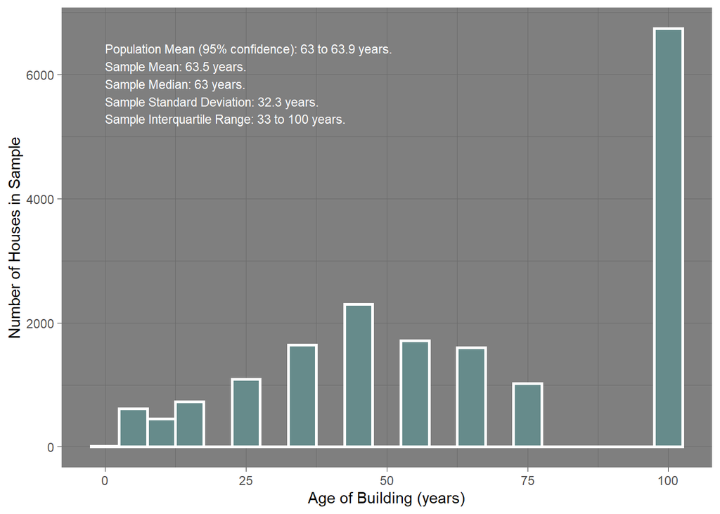

```r
ggplot(hh_data,
                   aes(x = age_struct)) +
  geom_histogram(color= "white", size = 1, fill = "paleturquoise4", binwidth = 5) +
  theme_gray() +
  scale_x_continuous(name = "Age of Building (years)") +
  scale_y_continuous(name = "Number of Houses in Sample") +
  annotate("text", color = "white", x = 0, y = 6500, size = 3,
           label = paste("Population Mean (95% confidence): 63 to 63.9 years.
Sample Mean: 63.5 years.
Sample Median: 63 years.
Sample Standard Deviation: 32.3 years.
Sample Interquartile Range: 33 to 100 years."),
           hjust = 0, vjust = 1) +

theme_dark()
```

The average age of household buildings in Massachusetts is 63 years. The mean is higher than this because of the high quantity of homes that are 100 years or older. Half of the houses are 33 to 100 years old. This variable was a categorical variable that I transformed to a continuous variable, which accounts for why there are segmented bins.

#### Number of Bedrooms

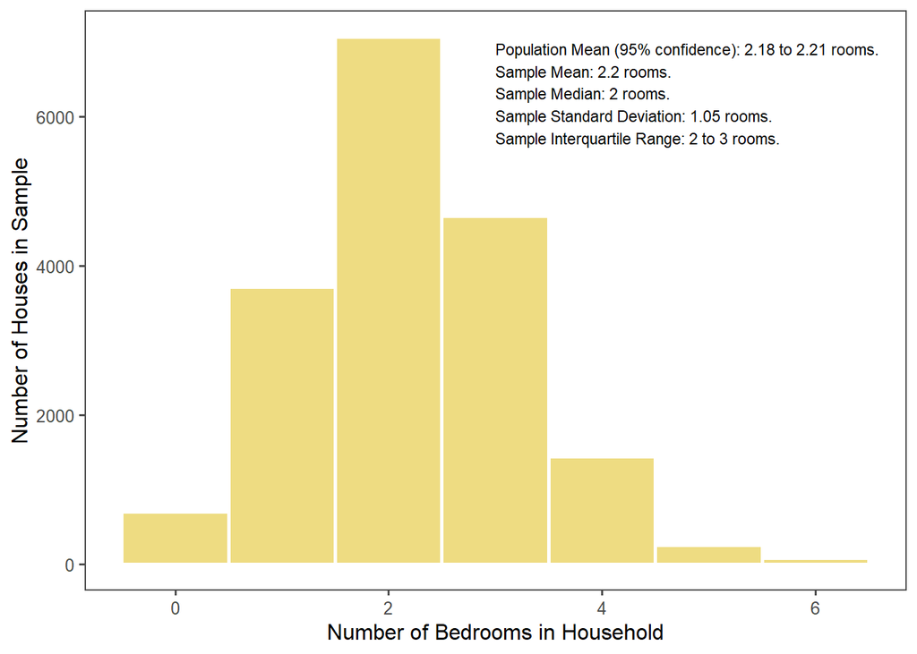

```r
ggplot(hh_data,
                   aes(x = bedrooms)) +
  geom_histogram(color= "white", size = 1, fill = "lightgoldenrod2", binwidth = 1) +
  theme_gray() +
  scale_x_continuous(name = "Number of Bedrooms in Household") +
  scale_y_continuous(name = "Number of Houses in Sample") +
  annotate("text", x = 3, y = 7000, size = 3,
           label = paste("Population Mean (95% confidence): 2.18 to 2.21 rooms.
Sample Mean: 2.2 rooms.
Sample Median: 2 rooms.
Sample Standard Deviation: 1.05 rooms.
Sample Interquartile Range: 2 to 3 rooms."),
           hjust = 0, vjust = 1) +
theme_few()
```

The distribution of number of bedrooms is relatively normal, with a slight right skew. The mean is higher than the median due to the outliers at 6 bedrooms.

#### Number of People in Household

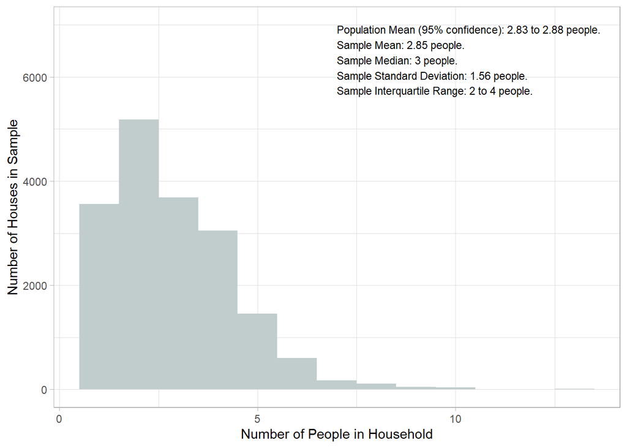

```r
ggplot(hh_data,
                   aes(x = num_persons)) +
  geom_histogram(fill = "azure3", binwidth = 1) +
  theme_gray() +
  scale_x_continuous(name = "Number of People in Household") +
  scale_y_continuous(name = "Number of Houses in Sample") +
  annotate("text", x = 7, y = 7000, size = 3,
           label = paste("Population Mean (95% confidence): 2.83 to 2.88 people.
Sample Mean: 2.85 people.
Sample Median: 3 people.
Sample Standard Deviation: 1.56 people.
Sample Interquartile Range: 2 to 4 people."),
           hjust = 0, vjust = 1) +

theme_light()
```

The distribution of the number of people in households has a right skew with a long tail. Half of households consist of 2 to 4 people. This might be closer to a Poisson distribution?

#### Years lived at Household

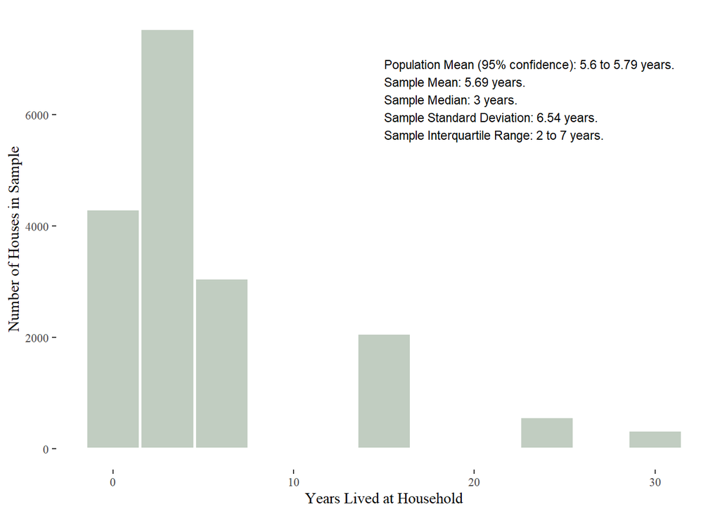

```r
ggplot(hh_data,
                   aes(x = move_in)) +
  geom_histogram(color= "white", size = 1, fill = "honeydew3", binwidth = 3) +
  theme_gray() +
  scale_x_continuous(name = "Years Lived at Household") +
  scale_y_continuous(name = "Number of Houses in Sample") +
  annotate("text", x = 15, y = 7000, size = 3,
           label = paste("Population Mean (95% confidence): 5.6 to 5.79 years.
Sample Mean: 5.69 years.
Sample Median: 3 years.
Sample Standard Deviation: 6.54 years.
Sample Interquartile Range: 2 to 7 years."),
           hjust = 0, vjust = 1) +

theme_tufte()
```

#### Gross Rent

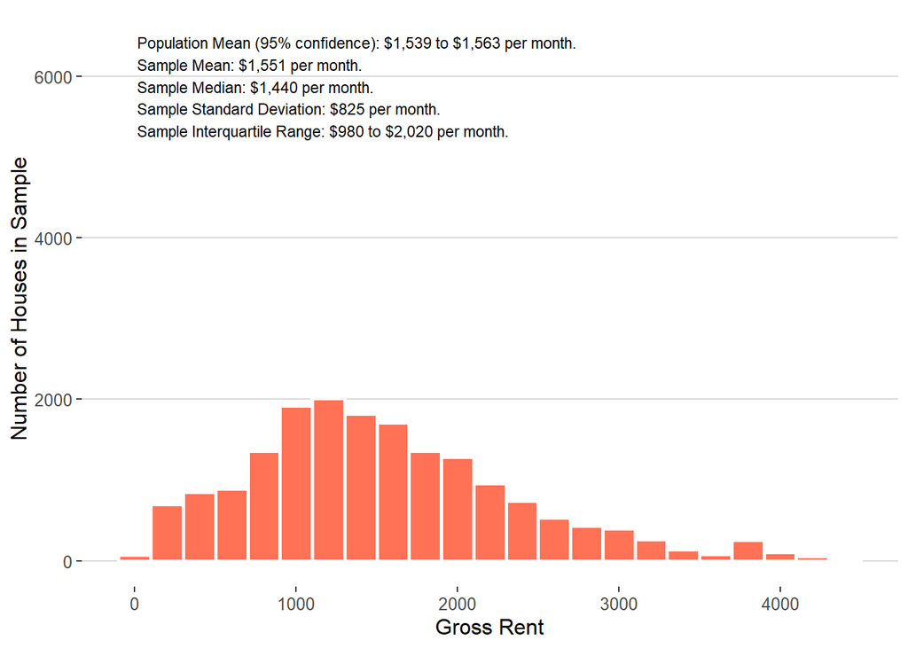

```r
ggplot(hh_data,
                   aes(x = gross_rent)) +
  geom_histogram(color= "white", size = 1, fill = "coral1", binwidth = 200) +
  theme_gray() +
  scale_x_continuous(name = "Gross Rent") +
  scale_y_continuous(name = "Number of Houses in Sample") +
  annotate("text", x = 15, y = 6500, size = 3,
           label = paste("Population Mean (95% confidence): $1,539 to $1,563 per month.
Sample Mean: $1,551 per month.
Sample Median: $1,440 per month.
Sample Standard Deviation: $825 per month.
Sample Interquartile Range: $980 to $2,020 per month."),
           hjust = 0, vjust = 1) +

theme_hc()
```

The average household pays 1,551 dollars per month, but the median is lower because of the high number of rent amounts around 1000 to 1300 dollars per month. Half of households pay 980 to 2,020 dollars per month. The distribution has a right skew, with a tail of rent prices much higher.

## Distribution of Categorical Variables

#### Household Types

```r
household_types <- unique(HHT_label)
household_types
```

```
## [1] "Nonfamily household: Male householder: Not living alone"
## [2] "Nonfamily household: Female householder: Living alone"
## [3] "Nonfamily household: Female householder: Not living alone"
## [4] "Nonfamily household: Male householder: Living alone"
## [5] "Married couple household"
## [6] "Other family household: Female householder, no spouse present"
## [7] "Other family household: Male householder, no spouse present"
```

```r
married_couple <- t.test(HHT_label == household_types[5])
non_family_m <- t.test(HHT_label == household_types[1])
non_family_f <- t.test(HHT_label == household_types[2])
living_alone_m <- t.test(HHT_label == household_types[4])
living_alone_f <- t.test(HHT_label == household_types[2])
other_family_f <- t.test(HHT_label == household_types[6])
other_family_m <- t.test(HHT_label == household_types[7])
shares <- tibble(Household_Type = c("Married Couple",
                                    "Non-Family Male",
                                    "Non-Family Female",
                                    "Living Alone Male",
                                    "Living Alone Female",
                                    "Other Family Male",
                                    "Other Family Female"),
                 `Share` = c(married_couple$estimate,
                             non_family_m$estimate,
                             non_family_f$estimate,
                             living_alone_m$estimate,
                             living_alone_f$estimate,
                             other_family_m$estimate,
                             other_family_f$estimate),
                 Low = c(married_couple$conf.int[1],
                         non_family_m$conf.int[1],
                         non_family_f$conf.int[1],
                         living_alone_m$conf.int[1],
                         living_alone_f$conf.int[1],
                         other_family_m$conf.int[1],
                         other_family_f$conf.int[1]),
                  High = c(married_couple$conf.int[2],
                         non_family_m$conf.int[2],
                         non_family_f$conf.int[2],
                         living_alone_m$conf.int[2],
                         living_alone_f$conf.int[2],
                         other_family_m$conf.int[2],
                         other_family_f$conf.int[2]),)
knitr::kable(shares,caption = "Proportions and 95-Percent Confidence Intervals")
```

Proportions and 95-Percent Confidence Intervals

| Household_Type | Share | Low | High |
| --- | --- | --- | --- |
| Married Couple | 0.3418703 | 0.3349252 | 0.3488155 |
| Non-Family Male | 0.0992635 | 0.0948853 | 0.1036416 |
| Non-Family Female | 0.1147751 | 0.1101080 | 0.1194422 |
| Living Alone Male | 0.0839750 | 0.0799141 | 0.0880359 |
| Living Alone Female | 0.1147751 | 0.1101080 | 0.1194422 |
| Other Family Male | 0.0581408 | 0.0547145 | 0.0615672 |
| Other Family Female | 0.2112487 | 0.2052720 | 0.2172255 |

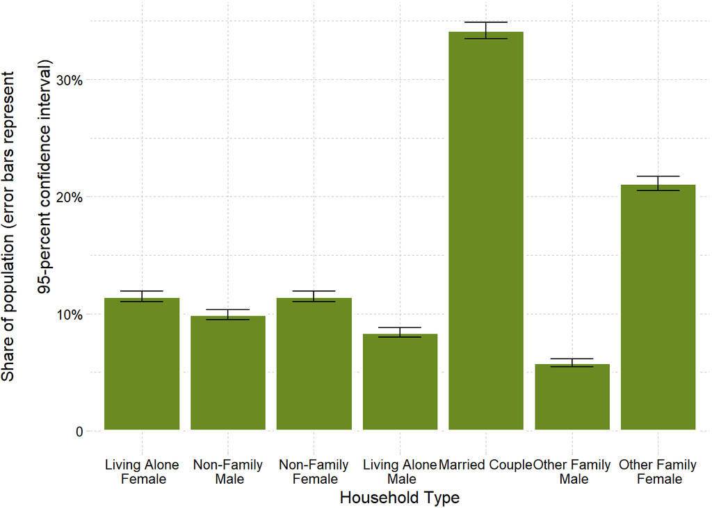

```r
ggplot(shares, aes(x = household_types, y = Share, ymin = Low, ymax = High)) +
  geom_bar(stat = "identity", color = "white", size = 1, fill = "olivedrab4") +
  geom_errorbar(width = 0.5) +
  theme_gray() +
  scale_x_discrete(name = "Household Type", labels = c("Living Alone\n Female",
                                    "Non-Family\n Male",
                                    "Non-Family\n Female",
                                    "Living Alone\n Male",
                                    "Married Couple",
                                    "Other Family\n Male",
                                    "Other Family\n Female")) +
  scale_y_continuous(name = "Share of population (error bars represent\n
                     95-percent confidence interval)",
                     breaks = c(0, 0.1, 0.2, 0.3, 0.4, 0.5),
                     labels = c("0", "10%", "20%", "30%", "40%", "50%")) +

  theme_pander()
```

#### Number of Units in Building

```r
units <- unique(BLD_label)
units
```

```
##  [1] "50 or more apartments"     "3-4 Apartments"
##  [3] "10-19 Apartments"          "5-9 Apartments"
##  [5] "2 Apartments"              "20-49 Apartments"
##  [7] "One-family house detached" "One-family house attached"
##  [9] "Mobile home or trailer"    "Boat, RV, van, etc."
```

```r
table(hh_data$BLD_label)
```

```
##
##          10-19 Apartments              2 Apartments          20-49 Apartments
##                      1430                      3034                      1469
##            3-4 Apartments            5-9 Apartments     50 or more apartments
##                      4434                      2140                      2284
##       Boat, RV, van, etc.    Mobile home or trailer One-family house attached
##                         2                        44                      1288
## One-family house detached
##                      1797
```

```r
two <- t.test(BLD_label == units[5])
three_4 <- t.test(BLD_label == units[2])
five_9 <- t.test(BLD_label == units[4])
ten_19 <- t.test(BLD_label == units[3])
twenty_49 <- t.test(BLD_label == units[6])
fifty <- t.test(BLD_label == units[1])
one_detached <- t.test(BLD_label == units[7])
one_attached <- t.test(BLD_label == units[8])
mobile <- t.test(BLD_label == units[9])
boat_rv <- t.test(BLD_label == units[10])
shares <- tibble(units = c("2 Apartments",
                                   "3-4 Apartments",
                                   "5-9 Apartments",
                                   "10-19 Apartments",
                                   "20-49 Apartments",
                                   "50 or more apartments",
                                   "One-family house detached",
                                   "One-family house attached",
                                   "Mobile home or trailer"   ,
                                   "Boat, RV, van, etc." ),
                 `Share` = c(two$estimate,
                             three_4$estimate,
                             five_9$estimate,
                             ten_19$estimate,
                             twenty_49$estimate,
                             fifty$estimate,
                             one_detached$estimate,
                             one_attached$estimate,
                             mobile$estimate,
                             boat_rv$estimate),
                 Low = c(two$conf.int[1],
                             three_4$conf.int[1],
                             five_9$conf.int[1],
                             ten_19$conf.int[1],
                             twenty_49$conf.int[1],
                             fifty$conf.int[1],
                             one_detached$conf.int[1],
                             one_attached$conf.int[1],
                             mobile$conf.int[1],
                             boat_rv$conf.int[1]),
                  High = c(two$conf.int[2],
                             three_4$conf.int[2],
                             five_9$conf.int[2],
                             ten_19$conf.int[2],
                             twenty_49$conf.int[2],
                             fifty$conf.int[2],
                             one_detached$conf.int[2],
                             one_attached$conf.int[2],
                             mobile$conf.int[2],
                             boat_rv$conf.int[2]),)
knitr::kable(shares,caption = "Proportions and 95-Percent Confidence Intervals")
```

Proportions and 95-Percent Confidence Intervals

| units | Share | Low | High |
| --- | --- | --- | --- |
| 2 Apartments | 0.1692891 | 0.1637983 | 0.1747799 |
| 3-4 Apartments | 0.2474054 | 0.2410874 | 0.2537235 |
| 5-9 Apartments | 0.1194063 | 0.1146585 | 0.1241542 |
| 10-19 Apartments | 0.0797902 | 0.0758227 | 0.0837577 |
| 20-49 Apartments | 0.0819663 | 0.0779498 | 0.0859828 |
| 50 or more apartments | 0.1274411 | 0.1225586 | 0.1323237 |
| One-family house detached | 0.1002678 | 0.0958700 | 0.1046656 |
| One-family house attached | 0.0718670 | 0.0680855 | 0.0756485 |
| Mobile home or trailer | 0.0024551 | 0.0017305 | 0.0031797 |
| Boat, RV, van, etc. | 0.0001116 | -0.0000431 | 0.0002663 |

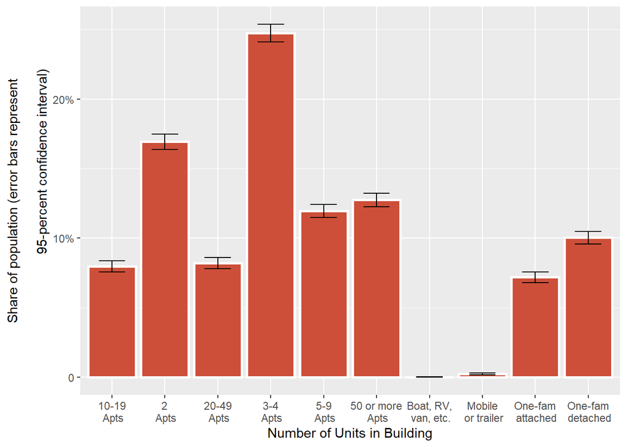

```r
ggplot(shares, aes(x = units, y = Share, ymin = Low, ymax = High)) +
  geom_bar(stat = "identity", color ="white", size = 1, fill = "tomato3") +
  geom_errorbar(width = 0.5) +
  theme_gray() +
  scale_x_discrete(name = "Number of Units in Building", labels = c("10-19\n Apts",
                                   "2\n Apts",
                                   "20-49\n Apts",
                                   "3-4\n Apts",
                                   "5-9\n Apts",
                                   "50 or more\n Apts",
                                   "Boat, RV,\n van, etc.",
                                   "Mobile\n or trailer",
                                   "One-fam\n attached",
                                   "One-fam\n detached")) +
  scale_y_continuous(name = "Share of population (error bars represent\n
                     95-percent confidence interval)",
                     breaks = c(0, 0.1, 0.2, 0.3, 0.4, 0.5),
                     labels = c("0", "10%", "20%", "30%", "40%", "50%")) +

theme_gray()
```

I’m surprised by this bar graph given that my sample is the state of Massachusetts, so I thought one family (attached and detached) households would be more common than apartment buildings.

# Assignment 2: Distributions and Proportions

Meghan Casey

September 17, 2020

### Variables of Interest

Unit of analysis: Household

Population: Renters in Massachusetts

1. Household Type (categorical): hh_type
2. Number of Units within Building (categorical): num_units
3. Age of Building (continuous): age_struct
4. Number of Bedrooms (continuous): bedrooms
5. Number of People (continuous): num_persons
6. Time Lived There (continuous): move_in
7. Gross Rent (continuous): gross_rent

### Load Libraries

```r
library(tidyverse)
library(ggplot2)
library(ggthemes)
```

### Load Data

```r
hh_data <- read_csv("households_ma.csv")
attach(hh_data)
```

## Distribution of Continuous Variables

### Summary of Statistics

```r
age_summary <- summary(age_struct)
age_sd <- sd(age_struct, na.rm = TRUE)
age_pop_mean_int <- t.test(age_struct)
bed_summary <- summary(bedrooms)
bed_sd <- sd(bedrooms, na.rm = TRUE)
bed_pop_mean_int <- t.test(bedrooms)
ppl_summary <- summary(num_persons)
ppl_sd <- sd(num_persons, na.rm = TRUE)
ppl_pop_mean_int <- t.test(num_persons)
live_summary <- summary(move_in)
live_sd <- sd(move_in, na.rm = TRUE)
live_pop_mean_int <- t.test(move_in)
rent_summary <- summary(gross_rent)
rent_sd <- sd(gross_rent, na.rm = TRUE)
rent_pop_mean_int <- t.test(gross_rent)
```

```r
summary_table <- tibble(
  Statistic = c("Sample mean",
                "Median",
                "Standard deviation",
                "Interquartile range",
                "Population mean (95% confidence)"),
  `Age of Structure (years)` = c(prettyNum(age_summary["Mean"], digits = 3),
                           age_summary["Median"],
                           prettyNum(age_sd, digits = 3),
                           paste(age_summary["1st Qu."],"to",
                                 age_summary["3rd Qu."]),
                           paste(prettyNum(age_pop_mean_int$conf.int[1],
                                           digits = 2), "to",
                                 prettyNum(age_pop_mean_int$conf.int[2],
                                               digits = 3))),

  `Number of Bedrooms` = c(prettyNum(bed_summary["Mean"], digits = 3),
                           bed_summary["Median"],
                           prettyNum(bed_sd, digits = 3),
                           paste(bed_summary["1st Qu."],"to",
                                 bed_summary["3rd Qu."]),
                           paste(prettyNum(bed_pop_mean_int$conf.int[1],
                                           digits = 3), "to",
                                 prettyNum(bed_pop_mean_int$conf.int[2],
                                               digits = 3))),

  `Number of Residents` = c(prettyNum(ppl_summary["Mean"], digits = 3),
                           ppl_summary["Median"],
                           prettyNum(ppl_sd, digits = 3),
                           paste(ppl_summary["1st Qu."],"to",
                                 ppl_summary["3rd Qu."]),
                           paste(prettyNum(ppl_pop_mean_int$conf.int[1],
                                           digits=3), "to",
                                 prettyNum(ppl_pop_mean_int$conf.int[2],
                                               digits=3))),

  `Years lived at House` = c(prettyNum(live_summary["Mean"], digits = 3),
                           live_summary["Median"],
                           prettyNum(live_sd, digits = 3),
                           paste(live_summary["1st Qu."],"to",
                                 live_summary["3rd Qu."]),
                           paste(prettyNum(live_pop_mean_int$conf.int[1],
                                           digits = 3), "to",
                                 prettyNum(live_pop_mean_int$conf.int[2],
                                               digits = 3))),

  `Gross Rent` = c(prettyNum(rent_summary["Mean"], digits=3),
                           rent_summary["Median"],
                           prettyNum(rent_sd, digits = 3),
                           paste(rent_summary["1st Qu."],"to",
                                 rent_summary["3rd Qu."]),
                           paste(prettyNum(rent_pop_mean_int$conf.int[1],
                                           digits=3), "to",
                                 prettyNum(rent_pop_mean_int$conf.int[2],
                                               digits=3))))

  knitr::kable(summary_table,
             caption = "Characteristics of rented households in Massachusetts")
```

Characteristics of rented households in Massachusetts

| Statistic | Age of Structure (years) | Number of Bedrooms | Number of Residents | Years lived at House | Gross Rent |
| --- | --- | --- | --- | --- | --- |
| Sample mean | 63.5 | 2.2 | 2.85 | 5.69 | 1551 |
| Median | 63 | 2 | 3 | 3 | 1440 |
| Standard deviation | 32.3 | 1.05 | 1.56 | 6.54 | 825 |
| Interquartile range | 33 to 100 | 2 to 3 | 2 to 4 | 2 to 7 | 980 to 2020 |
| Population mean (95% confidence) | 63 to 63.9 | 2.18 to 2.21 | 2.83 to 2.88 | 5.6 to 5.79 | 1539 to 1563 |

### Histograms

#### Age of Structure

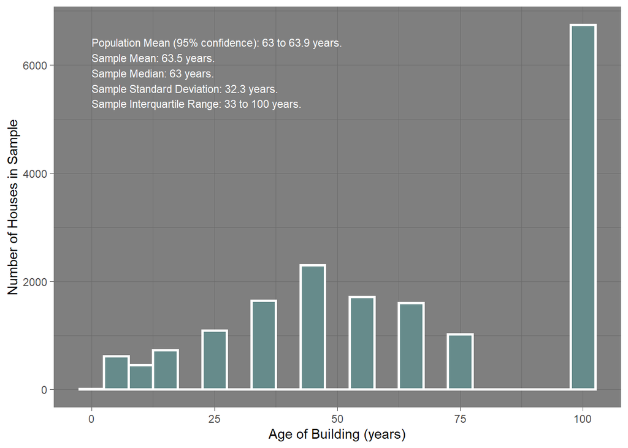

```r
ggplot(hh_data,
                   aes(x = age_struct)) +
  geom_histogram(color= "white", size = 1, fill = "paleturquoise4", binwidth = 5) +
  theme_gray() +
  scale_x_continuous(name = "Age of Building (years)") +
  scale_y_continuous(name = "Number of Houses in Sample") +
  annotate("text", color = "white", x = 0, y = 6500, size = 3,
           label = paste("Population Mean (95% confidence): 63 to 63.9 years.
Sample Mean: 63.5 years.
Sample Median: 63 years.
Sample Standard Deviation: 32.3 years.
Sample Interquartile Range: 33 to 100 years."),
           hjust = 0, vjust = 1) +

theme_dark()
```

The average age of household buildings in Massachusetts is 63 years. The mean is higher than this because of the high quantity of homes that are 100 years or older. Half of the houses are 33 to 100 years old. This variable was a categorical variable that I transformed to a continuous variable, which accounts for why there are segmented bins.

#### Number of Bedrooms

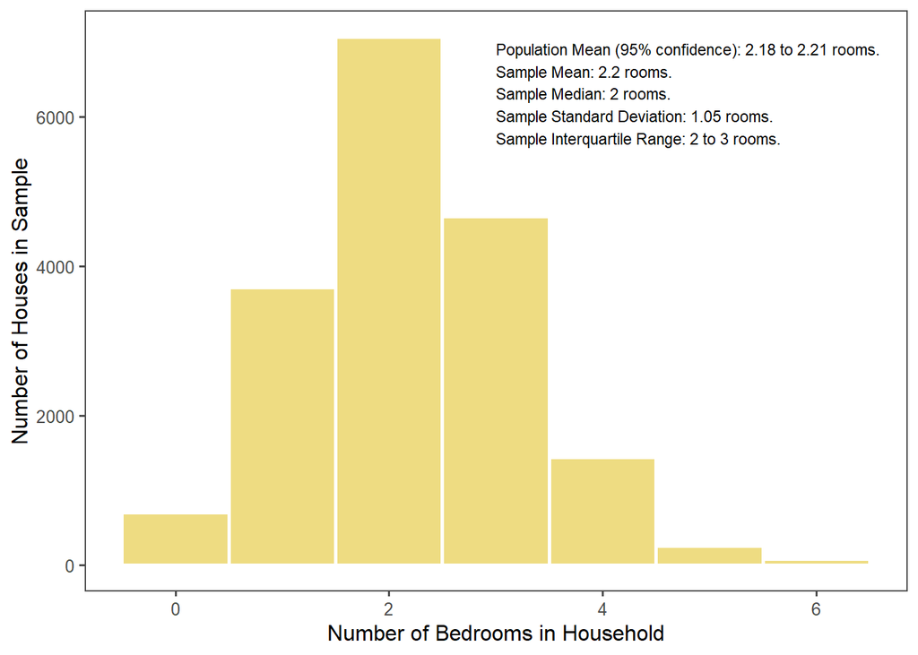

```r
ggplot(hh_data,
                   aes(x = bedrooms)) +
  geom_histogram(color= "white", size = 1, fill = "lightgoldenrod2", binwidth = 1) +
  theme_gray() +
  scale_x_continuous(name = "Number of Bedrooms in Household") +
  scale_y_continuous(name = "Number of Houses in Sample") +
  annotate("text", x = 3, y = 7000, size = 3,
           label = paste("Population Mean (95% confidence): 2.18 to 2.21 rooms.
Sample Mean: 2.2 rooms.
Sample Median: 2 rooms.
Sample Standard Deviation: 1.05 rooms.
Sample Interquartile Range: 2 to 3 rooms."),
           hjust = 0, vjust = 1) +
theme_few()
```

The distribution of number of bedrooms is relatively normal, with a slight right skew. The mean is higher than the median due to the outliers at 6 bedrooms.

#### Number of People in Household

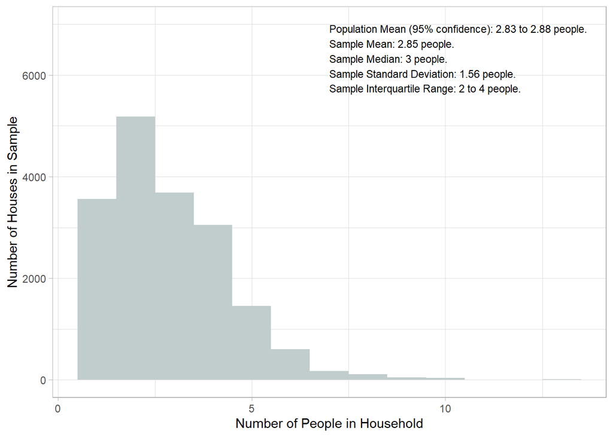

```r
ggplot(hh_data,
                   aes(x = num_persons)) +
  geom_histogram(fill = "azure3", binwidth = 1) +
  theme_gray() +
  scale_x_continuous(name = "Number of People in Household") +
  scale_y_continuous(name = "Number of Houses in Sample") +
  annotate("text", x = 7, y = 7000, size = 3,
           label = paste("Population Mean (95% confidence): 2.83 to 2.88 people.
Sample Mean: 2.85 people.
Sample Median: 3 people.
Sample Standard Deviation: 1.56 people.
Sample Interquartile Range: 2 to 4 people."),
           hjust = 0, vjust = 1) +

theme_light()
```

The distribution of the number of people in households has a right skew with a long tail. Half of households consist of 2 to 4 people. This might be closer to a Poisson distribution?

#### Years lived at Household

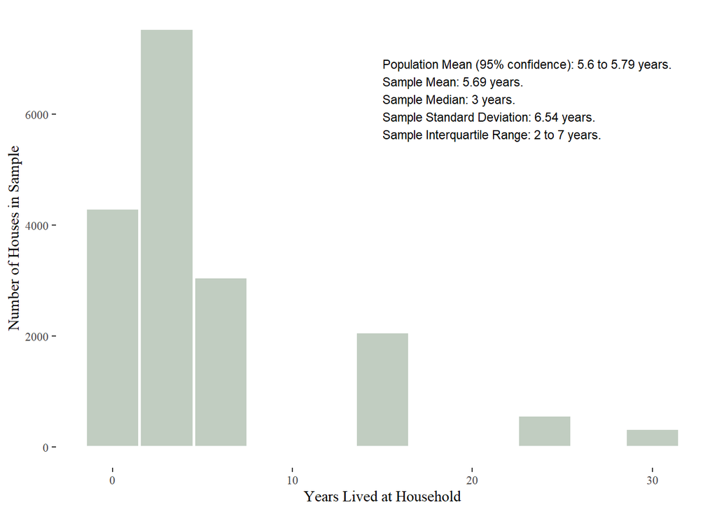

```r
ggplot(hh_data,
                   aes(x = move_in)) +
  geom_histogram(color= "white", size = 1, fill = "honeydew3", binwidth = 3) +
  theme_gray() +
  scale_x_continuous(name = "Years Lived at Household") +
  scale_y_continuous(name = "Number of Houses in Sample") +
  annotate("text", x = 15, y = 7000, size = 3,
           label = paste("Population Mean (95% confidence): 5.6 to 5.79 years.
Sample Mean: 5.69 years.
Sample Median: 3 years.
Sample Standard Deviation: 6.54 years.
Sample Interquartile Range: 2 to 7 years."),
           hjust = 0, vjust = 1) +

theme_tufte()
```

#### Gross Rent

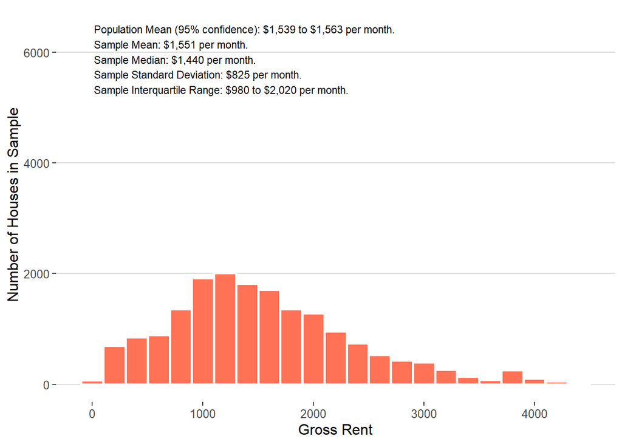

```r
ggplot(hh_data,
                   aes(x = gross_rent)) +
  geom_histogram(color= "white", size = 1, fill = "coral1", binwidth = 200) +
  theme_gray() +
  scale_x_continuous(name = "Gross Rent") +
  scale_y_continuous(name = "Number of Houses in Sample") +
  annotate("text", x = 15, y = 6500, size = 3,
           label = paste("Population Mean (95% confidence): $1,539 to $1,563 per month.
Sample Mean: $1,551 per month.
Sample Median: $1,440 per month.
Sample Standard Deviation: $825 per month.
Sample Interquartile Range: $980 to $2,020 per month."),
           hjust = 0, vjust = 1) +

theme_hc()
```

The average household pays 1,551 dollars per month, but the median is lower because of the high number of rent amounts around 1000 to 1300 dollars per month. Half of households pay 980 to 2,020 dollars per month. The distribution has a right skew, with a tail of rent prices much higher.

## Distribution of Categorical Variables

#### Household Types

```r
household_types <- unique(HHT_label)
household_types
```

```
## [1] "Nonfamily household: Male householder: Not living alone"
## [2] "Nonfamily household: Female householder: Living alone"
## [3] "Nonfamily household: Female householder: Not living alone"
## [4] "Nonfamily household: Male householder: Living alone"
## [5] "Married couple household"
## [6] "Other family household: Female householder, no spouse present"
## [7] "Other family household: Male householder, no spouse present"
```

```r
married_couple <- t.test(HHT_label == household_types[5])
non_family_m <- t.test(HHT_label == household_types[1])
non_family_f <- t.test(HHT_label == household_types[2])
living_alone_m <- t.test(HHT_label == household_types[4])
living_alone_f <- t.test(HHT_label == household_types[2])
other_family_f <- t.test(HHT_label == household_types[6])
other_family_m <- t.test(HHT_label == household_types[7])
shares <- tibble(Household_Type = c("Married Couple",
                                    "Non-Family Male",
                                    "Non-Family Female",
                                    "Living Alone Male",
                                    "Living Alone Female",
                                    "Other Family Male",
                                    "Other Family Female"),
                 `Share` = c(married_couple$estimate,
                             non_family_m$estimate,
                             non_family_f$estimate,
                             living_alone_m$estimate,
                             living_alone_f$estimate,
                             other_family_m$estimate,
                             other_family_f$estimate),
                 Low = c(married_couple$conf.int[1],
                         non_family_m$conf.int[1],
                         non_family_f$conf.int[1],
                         living_alone_m$conf.int[1],
                         living_alone_f$conf.int[1],
                         other_family_m$conf.int[1],
                         other_family_f$conf.int[1]),
                  High = c(married_couple$conf.int[2],
                         non_family_m$conf.int[2],
                         non_family_f$conf.int[2],
                         living_alone_m$conf.int[2],
                         living_alone_f$conf.int[2],
                         other_family_m$conf.int[2],
                         other_family_f$conf.int[2]),)
knitr::kable(shares,caption = "Proportions and 95-Percent Confidence Intervals")
```

Proportions and 95-Percent Confidence Intervals

| Household_Type | Share | Low | High |
| --- | --- | --- | --- |
| Married Couple | 0.3418703 | 0.3349252 | 0.3488155 |
| Non-Family Male | 0.0992635 | 0.0948853 | 0.1036416 |
| Non-Family Female | 0.1147751 | 0.1101080 | 0.1194422 |
| Living Alone Male | 0.0839750 | 0.0799141 | 0.0880359 |
| Living Alone Female | 0.1147751 | 0.1101080 | 0.1194422 |
| Other Family Male | 0.0581408 | 0.0547145 | 0.0615672 |
| Other Family Female | 0.2112487 | 0.2052720 | 0.2172255 |

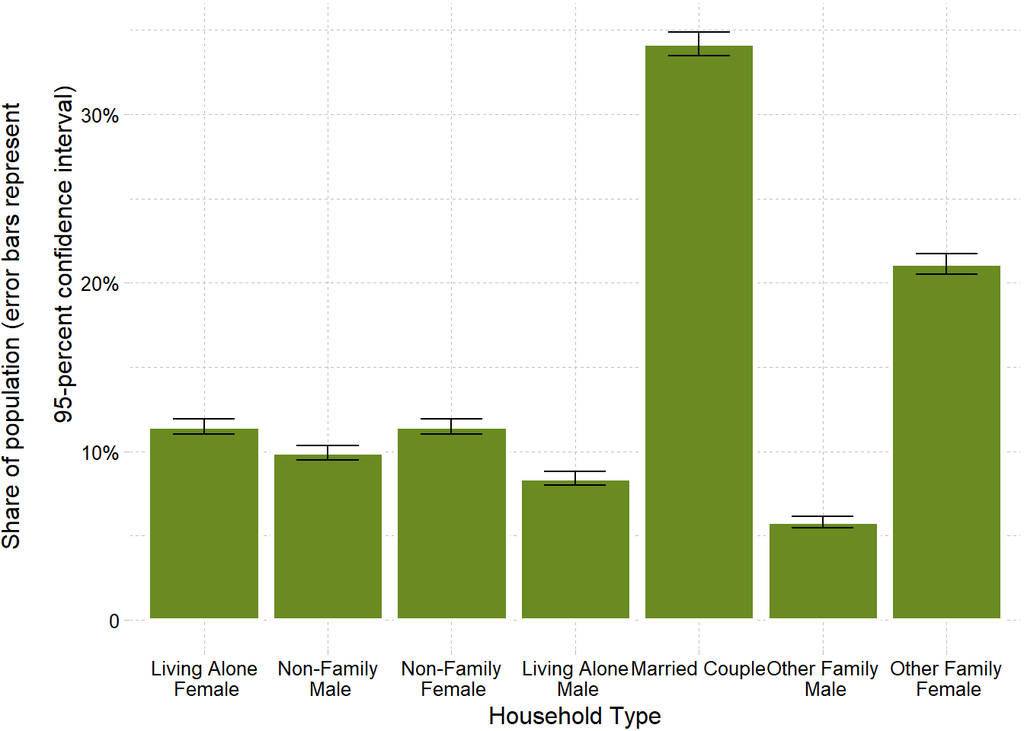

```r
ggplot(shares, aes(x = household_types, y = Share, ymin = Low, ymax = High)) +
  geom_bar(stat = "identity", color = "white", size = 1, fill = "olivedrab4") +
  geom_errorbar(width = 0.5) +
  theme_gray() +
  scale_x_discrete(name = "Household Type", labels = c("Living Alone\n Female",
                                    "Non-Family\n Male",
                                    "Non-Family\n Female",
                                    "Living Alone\n Male",
                                    "Married Couple",
                                    "Other Family\n Male",
                                    "Other Family\n Female")) +
  scale_y_continuous(name = "Share of population (error bars represent\n
                     95-percent confidence interval)",
                     breaks = c(0, 0.1, 0.2, 0.3, 0.4, 0.5),
                     labels = c("0", "10%", "20%", "30%", "40%", "50%")) +

  theme_pander()
```

#### Number of Units in Building

```r
units <- unique(BLD_label)
units
```

```
##  [1] "50 or more apartments"     "3-4 Apartments"
##  [3] "10-19 Apartments"          "5-9 Apartments"
##  [5] "2 Apartments"              "20-49 Apartments"
##  [7] "One-family house detached" "One-family house attached"
##  [9] "Mobile home or trailer"    "Boat, RV, van, etc."
```

```r
table(hh_data$BLD_label)
```

```
##
##          10-19 Apartments              2 Apartments          20-49 Apartments
##                      1430                      3034                      1469
##            3-4 Apartments            5-9 Apartments     50 or more apartments
##                      4434                      2140                      2284
##       Boat, RV, van, etc.    Mobile home or trailer One-family house attached
##                         2                        44                      1288
## One-family house detached
##                      1797
```

```r
two <- t.test(BLD_label == units[5])
three_4 <- t.test(BLD_label == units[2])
five_9 <- t.test(BLD_label == units[4])
ten_19 <- t.test(BLD_label == units[3])
twenty_49 <- t.test(BLD_label == units[6])
fifty <- t.test(BLD_label == units[1])
one_detached <- t.test(BLD_label == units[7])
one_attached <- t.test(BLD_label == units[8])
mobile <- t.test(BLD_label == units[9])
boat_rv <- t.test(BLD_label == units[10])
shares <- tibble(units = c("2 Apartments",
                                   "3-4 Apartments",
                                   "5-9 Apartments",
                                   "10-19 Apartments",
                                   "20-49 Apartments",
                                   "50 or more apartments",
                                   "One-family house detached",
                                   "One-family house attached",
                                   "Mobile home or trailer"   ,
                                   "Boat, RV, van, etc." ),
                 `Share` = c(two$estimate,
                             three_4$estimate,
                             five_9$estimate,
                             ten_19$estimate,
                             twenty_49$estimate,
                             fifty$estimate,
                             one_detached$estimate,
                             one_attached$estimate,
                             mobile$estimate,
                             boat_rv$estimate),
                 Low = c(two$conf.int[1],
                             three_4$conf.int[1],
                             five_9$conf.int[1],
                             ten_19$conf.int[1],
                             twenty_49$conf.int[1],
                             fifty$conf.int[1],
                             one_detached$conf.int[1],
                             one_attached$conf.int[1],
                             mobile$conf.int[1],
                             boat_rv$conf.int[1]),
                  High = c(two$conf.int[2],
                             three_4$conf.int[2],
                             five_9$conf.int[2],
                             ten_19$conf.int[2],
                             twenty_49$conf.int[2],
                             fifty$conf.int[2],
                             one_detached$conf.int[2],
                             one_attached$conf.int[2],
                             mobile$conf.int[2],
                             boat_rv$conf.int[2]),)
knitr::kable(shares,caption = "Proportions and 95-Percent Confidence Intervals")
```

Proportions and 95-Percent Confidence Intervals

| units | Share | Low | High |
| --- | --- | --- | --- |
| 2 Apartments | 0.1692891 | 0.1637983 | 0.1747799 |
| 3-4 Apartments | 0.2474054 | 0.2410874 | 0.2537235 |
| 5-9 Apartments | 0.1194063 | 0.1146585 | 0.1241542 |
| 10-19 Apartments | 0.0797902 | 0.0758227 | 0.0837577 |
| 20-49 Apartments | 0.0819663 | 0.0779498 | 0.0859828 |
| 50 or more apartments | 0.1274411 | 0.1225586 | 0.1323237 |
| One-family house detached | 0.1002678 | 0.0958700 | 0.1046656 |
| One-family house attached | 0.0718670 | 0.0680855 | 0.0756485 |
| Mobile home or trailer | 0.0024551 | 0.0017305 | 0.0031797 |
| Boat, RV, van, etc. | 0.0001116 | -0.0000431 | 0.0002663 |

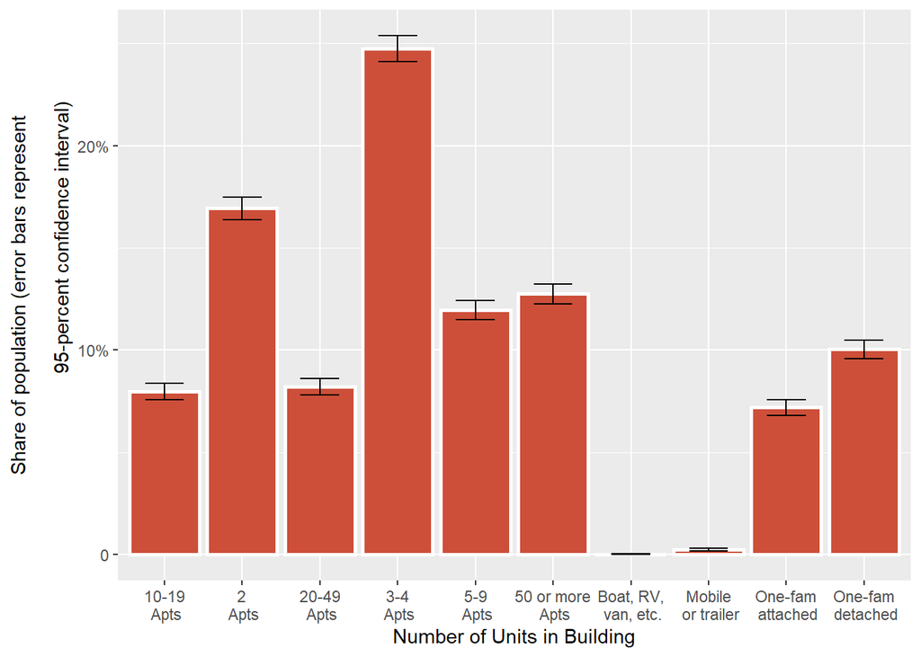

```r
ggplot(shares, aes(x = units, y = Share, ymin = Low, ymax = High)) +
  geom_bar(stat = "identity", color ="white", size = 1, fill = "tomato3") +
  geom_errorbar(width = 0.5) +
  theme_gray() +
  scale_x_discrete(name = "Number of Units in Building", labels = c("10-19\n Apts",
                                   "2\n Apts",
                                   "20-49\n Apts",
                                   "3-4\n Apts",
                                   "5-9\n Apts",
                                   "50 or more\n Apts",
                                   "Boat, RV,\n van, etc.",
                                   "Mobile\n or trailer",
                                   "One-fam\n attached",
                                   "One-fam\n detached")) +
  scale_y_continuous(name = "Share of population (error bars represent\n
                     95-percent confidence interval)",
                     breaks = c(0, 0.1, 0.2, 0.3, 0.4, 0.5),
                     labels = c("0", "10%", "20%", "30%", "40%", "50%")) +

theme_gray()
```

I’m surprised by this bar graph given that my sample is the state of Massachusetts, so I thought one family (attached and detached) households would be more common than apartment buildings.